# Risk Factor Analysis

## Outcome Variable

**Outcome Variable:** stunted

## Predictor Variables

**Intervention Variable:** single

**Adjustment Set:**

unadjusted

## Stratifying Variables

The analysis was stratified on these variable(s):

- agecat
- studyid
- country

## Data Summary

| agecat | studyid | country | A | n | nA | nAY0 | nAY1 |
| --- | --- | --- | --- | --- | --- | --- | --- |
| Birth | ki0047075b-MAL-ED | BANGLADESH | 0 | 257 | 257 | 210 | 47 |
| Birth | ki0047075b-MAL-ED | BANGLADESH | 1 | 257 | 0 | 0 | 0 |
| Birth | ki0047075b-MAL-ED | BRAZIL | 0 | 191 | 166 | 151 | 15 |
| Birth | ki0047075b-MAL-ED | BRAZIL | 1 | 191 | 25 | 19 | 6 |
| Birth | ki0047075b-MAL-ED | INDIA | 0 | 205 | 205 | 173 | 32 |
| Birth | ki0047075b-MAL-ED | INDIA | 1 | 205 | 0 | 0 | 0 |
| Birth | ki0047075b-MAL-ED | NEPAL | 0 | 173 | 173 | 155 | 18 |
| Birth | ki0047075b-MAL-ED | NEPAL | 1 | 173 | 0 | 0 | 0 |
| Birth | ki0047075b-MAL-ED | PERU | 0 | 287 | 253 | 226 | 27 |
| Birth | ki0047075b-MAL-ED | PERU | 1 | 287 | 34 | 27 | 7 |
| Birth | ki0047075b-MAL-ED | SOUTH AFRICA | 0 | 262 | 146 | 133 | 13 |
| Birth | ki0047075b-MAL-ED | SOUTH AFRICA | 1 | 262 | 116 | 101 | 15 |
| Birth | ki0047075b-MAL-ED | TANZANIA, UNITED REPUBLIC OF | 0 | 123 | 117 | 100 | 17 |
| Birth | ki0047075b-MAL-ED | TANZANIA, UNITED REPUBLIC OF | 1 | 123 | 6 | 5 | 1 |
| Birth | ki1119695-PROBIT | BELARUS | 0 | 6779 | 6540 | 6519 | 21 |
| Birth | ki1119695-PROBIT | BELARUS | 1 | 6779 | 239 | 239 | 0 |
| Birth | ki1126311-ZVITAMBO | ZIMBABWE | 0 | 13772 | 12902 | 11582 | 1320 |
| Birth | ki1126311-ZVITAMBO | ZIMBABWE | 1 | 13772 | 870 | 763 | 107 |
| Birth | ki1135781-COHORTS | GUATEMALA | 0 | 363 | 334 | 318 | 16 |
| Birth | ki1135781-COHORTS | GUATEMALA | 1 | 363 | 29 | 28 | 1 |
| Birth | ki1135781-COHORTS | INDIA | 0 | 4778 | 4771 | 4206 | 565 |
| Birth | ki1135781-COHORTS | INDIA | 1 | 4778 | 7 | 7 | 0 |
| Birth | ki1135781-COHORTS | PHILIPPINES | 0 | 3010 | 2936 | 2760 | 176 |
| Birth | ki1135781-COHORTS | PHILIPPINES | 1 | 3010 | 74 | 68 | 6 |
| 3 months | ki0047075b-MAL-ED | BANGLADESH | 0 | 250 | 250 | 207 | 43 |
| 3 months | ki0047075b-MAL-ED | BANGLADESH | 1 | 250 | 0 | 0 | 0 |
| 3 months | ki0047075b-MAL-ED | BRAZIL | 0 | 225 | 191 | 181 | 10 |
| 3 months | ki0047075b-MAL-ED | BRAZIL | 1 | 225 | 34 | 30 | 4 |
| 3 months | ki0047075b-MAL-ED | INDIA | 0 | 239 | 239 | 205 | 34 |
| 3 months | ki0047075b-MAL-ED | INDIA | 1 | 239 | 0 | 0 | 0 |

[output cut: 156 more lines]

The following strata were considered:

- agecat: 12 months, studyid: ki0047075b-MAL-ED, country: BANGLADESH
- agecat: 12 months, studyid: ki0047075b-MAL-ED, country: BRAZIL
- agecat: 12 months, studyid: ki0047075b-MAL-ED, country: INDIA
- agecat: 12 months, studyid: ki0047075b-MAL-ED, country: NEPAL
- agecat: 12 months, studyid: ki0047075b-MAL-ED, country: PERU
- agecat: 12 months, studyid: ki0047075b-MAL-ED, country: SOUTH AFRICA
- agecat: 12 months, studyid: ki0047075b-MAL-ED, country: TANZANIA, UNITED REPUBLIC OF
- agecat: 12 months, studyid: ki1066203-TanzaniaChild2, country: TANZANIA, UNITED REPUBLIC OF
- agecat: 12 months, studyid: ki1112895-Guatemala BSC, country: GUATEMALA
- agecat: 12 months, studyid: ki1119695-PROBIT, country: BELARUS
- agecat: 12 months, studyid: ki1126311-ZVITAMBO, country: ZIMBABWE
- agecat: 12 months, studyid: ki1135781-COHORTS, country: GUATEMALA
- agecat: 12 months, studyid: ki1135781-COHORTS, country: INDIA
- agecat: 12 months, studyid: ki1135781-COHORTS, country: PHILIPPINES
- agecat: 18 months, studyid: ki0047075b-MAL-ED, country: BANGLADESH
- agecat: 18 months, studyid: ki0047075b-MAL-ED, country: BRAZIL
- agecat: 18 months, studyid: ki0047075b-MAL-ED, country: INDIA
- agecat: 18 months, studyid: ki0047075b-MAL-ED, country: NEPAL
- agecat: 18 months, studyid: ki0047075b-MAL-ED, country: PERU
- agecat: 18 months, studyid: ki0047075b-MAL-ED, country: SOUTH AFRICA
- agecat: 18 months, studyid: ki0047075b-MAL-ED, country: TANZANIA, UNITED REPUBLIC OF
- agecat: 18 months, studyid: ki1066203-TanzaniaChild2, country: TANZANIA, UNITED REPUBLIC OF
- agecat: 18 months, studyid: ki1119695-PROBIT, country: BELARUS
- agecat: 18 months, studyid: ki1126311-ZVITAMBO, country: ZIMBABWE
- agecat: 18 months, studyid: ki1135781-COHORTS, country: GUATEMALA
- agecat: 18 months, studyid: ki1135781-COHORTS, country: PHILIPPINES
- agecat: 24 months, studyid: ki0047075b-MAL-ED, country: BANGLADESH
- agecat: 24 months, studyid: ki0047075b-MAL-ED, country: BRAZIL
- agecat: 24 months, studyid: ki0047075b-MAL-ED, country: INDIA
- agecat: 24 months, studyid: ki0047075b-MAL-ED, country: NEPAL
- agecat: 24 months, studyid: ki0047075b-MAL-ED, country: PERU
- agecat: 24 months, studyid: ki0047075b-MAL-ED, country: SOUTH AFRICA
- agecat: 24 months, studyid: ki0047075b-MAL-ED, country: TANZANIA, UNITED REPUBLIC OF
- agecat: 24 months, studyid: ki1066203-TanzaniaChild2, country: TANZANIA, UNITED REPUBLIC OF
- agecat: 24 months, studyid: ki1119695-PROBIT, country: BELARUS
- agecat: 24 months, studyid: ki1126311-ZVITAMBO, country: ZIMBABWE
- agecat: 24 months, studyid: ki1135781-COHORTS, country: GUATEMALA
- agecat: 24 months, studyid: ki1135781-COHORTS, country: INDIA
- agecat: 24 months, studyid: ki1135781-COHORTS, country: PHILIPPINES
- agecat: 3 months, studyid: ki0047075b-MAL-ED, country: BANGLADESH
- agecat: 3 months, studyid: ki0047075b-MAL-ED, country: BRAZIL
- agecat: 3 months, studyid: ki0047075b-MAL-ED, country: INDIA
- agecat: 3 months, studyid: ki0047075b-MAL-ED, country: NEPAL
- agecat: 3 months, studyid: ki0047075b-MAL-ED, country: PERU
- agecat: 3 months, studyid: ki0047075b-MAL-ED, country: SOUTH AFRICA
- agecat: 3 months, studyid: ki0047075b-MAL-ED, country: TANZANIA, UNITED REPUBLIC OF
- agecat: 3 months, studyid: ki1066203-TanzaniaChild2, country: TANZANIA, UNITED REPUBLIC OF
- agecat: 3 months, studyid: ki1112895-Guatemala BSC, country: GUATEMALA
- agecat: 3 months, studyid: ki1119695-PROBIT, country: BELARUS
- agecat: 3 months, studyid: ki1126311-ZVITAMBO, country: ZIMBABWE
- agecat: 3 months, studyid: ki1135781-COHORTS, country: GUATEMALA
- agecat: 3 months, studyid: ki1135781-COHORTS, country: INDIA
- agecat: 3 months, studyid: ki1135781-COHORTS, country: PHILIPPINES
- agecat: 6 months, studyid: ki0047075b-MAL-ED, country: BANGLADESH
- agecat: 6 months, studyid: ki0047075b-MAL-ED, country: BRAZIL
- agecat: 6 months, studyid: ki0047075b-MAL-ED, country: INDIA
- agecat: 6 months, studyid: ki0047075b-MAL-ED, country: NEPAL
- agecat: 6 months, studyid: ki0047075b-MAL-ED, country: PERU
- agecat: 6 months, studyid: ki0047075b-MAL-ED, country: SOUTH AFRICA
- agecat: 6 months, studyid: ki0047075b-MAL-ED, country: TANZANIA, UNITED REPUBLIC OF
- agecat: 6 months, studyid: ki1066203-TanzaniaChild2, country: TANZANIA, UNITED REPUBLIC OF
- agecat: 6 months, studyid: ki1112895-Guatemala BSC, country: GUATEMALA
- agecat: 6 months, studyid: ki1119695-PROBIT, country: BELARUS
- agecat: 6 months, studyid: ki1126311-ZVITAMBO, country: ZIMBABWE
- agecat: 6 months, studyid: ki1135781-COHORTS, country: GUATEMALA
- agecat: 6 months, studyid: ki1135781-COHORTS, country: INDIA
- agecat: 6 months, studyid: ki1135781-COHORTS, country: PHILIPPINES
- agecat: 9 months, studyid: ki0047075b-MAL-ED, country: BANGLADESH
- agecat: 9 months, studyid: ki0047075b-MAL-ED, country: BRAZIL
- agecat: 9 months, studyid: ki0047075b-MAL-ED, country: INDIA
- agecat: 9 months, studyid: ki0047075b-MAL-ED, country: NEPAL
- agecat: 9 months, studyid: ki0047075b-MAL-ED, country: PERU
- agecat: 9 months, studyid: ki0047075b-MAL-ED, country: SOUTH AFRICA
- agecat: 9 months, studyid: ki0047075b-MAL-ED, country: TANZANIA, UNITED REPUBLIC OF
- agecat: 9 months, studyid: ki1066203-TanzaniaChild2, country: TANZANIA, UNITED REPUBLIC OF
- agecat: 9 months, studyid: ki1112895-Guatemala BSC, country: GUATEMALA
- agecat: 9 months, studyid: ki1119695-PROBIT, country: BELARUS
- agecat: 9 months, studyid: ki1126311-ZVITAMBO, country: ZIMBABWE
- agecat: 9 months, studyid: ki1135781-COHORTS, country: GUATEMALA
- agecat: 9 months, studyid: ki1135781-COHORTS, country: INDIA
- agecat: 9 months, studyid: ki1135781-COHORTS, country: PHILIPPINES
- agecat: Birth, studyid: ki0047075b-MAL-ED, country: BANGLADESH
- agecat: Birth, studyid: ki0047075b-MAL-ED, country: BRAZIL
- agecat: Birth, studyid: ki0047075b-MAL-ED, country: INDIA
- agecat: Birth, studyid: ki0047075b-MAL-ED, country: NEPAL
- agecat: Birth, studyid: ki0047075b-MAL-ED, country: PERU
- agecat: Birth, studyid: ki0047075b-MAL-ED, country: SOUTH AFRICA
- agecat: Birth, studyid: ki0047075b-MAL-ED, country: TANZANIA, UNITED REPUBLIC OF
- agecat: Birth, studyid: ki1119695-PROBIT, country: BELARUS
- agecat: Birth, studyid: ki1126311-ZVITAMBO, country: ZIMBABWE
- agecat: Birth, studyid: ki1135781-COHORTS, country: GUATEMALA
- agecat: Birth, studyid: ki1135781-COHORTS, country: INDIA
- agecat: Birth, studyid: ki1135781-COHORTS, country: PHILIPPINES

### Dropped Strata

Some strata were dropped due to rare outcomes:

- agecat: Birth, studyid: ki0047075b-MAL-ED, country: BANGLADESH
- agecat: Birth, studyid: ki0047075b-MAL-ED, country: INDIA
- agecat: Birth, studyid: ki0047075b-MAL-ED, country: NEPAL
- agecat: Birth, studyid: ki0047075b-MAL-ED, country: TANZANIA, UNITED REPUBLIC OF
- agecat: Birth, studyid: ki1119695-PROBIT, country: BELARUS
- agecat: Birth, studyid: ki1135781-COHORTS, country: GUATEMALA
- agecat: Birth, studyid: ki1135781-COHORTS, country: INDIA
- agecat: 3 months, studyid: ki0047075b-MAL-ED, country: BANGLADESH
- agecat: 3 months, studyid: ki0047075b-MAL-ED, country: BRAZIL
- agecat: 3 months, studyid: ki0047075b-MAL-ED, country: INDIA
- agecat: 3 months, studyid: ki0047075b-MAL-ED, country: NEPAL
- agecat: 3 months, studyid: ki0047075b-MAL-ED, country: TANZANIA, UNITED REPUBLIC OF
- agecat: 3 months, studyid: ki1112895-Guatemala BSC, country: GUATEMALA
- agecat: 3 months, studyid: ki1135781-COHORTS, country: INDIA
- agecat: 6 months, studyid: ki0047075b-MAL-ED, country: BANGLADESH
- agecat: 6 months, studyid: ki0047075b-MAL-ED, country: BRAZIL
- agecat: 6 months, studyid: ki0047075b-MAL-ED, country: INDIA
- agecat: 6 months, studyid: ki0047075b-MAL-ED, country: NEPAL
- agecat: 6 months, studyid: ki0047075b-MAL-ED, country: TANZANIA, UNITED REPUBLIC OF
- agecat: 6 months, studyid: ki1135781-COHORTS, country: INDIA
- agecat: 9 months, studyid: ki0047075b-MAL-ED, country: BANGLADESH
- agecat: 9 months, studyid: ki0047075b-MAL-ED, country: BRAZIL
- agecat: 9 months, studyid: ki0047075b-MAL-ED, country: INDIA
- agecat: 9 months, studyid: ki0047075b-MAL-ED, country: NEPAL
- agecat: 9 months, studyid: ki0047075b-MAL-ED, country: TANZANIA, UNITED REPUBLIC OF
- agecat: 9 months, studyid: ki1135781-COHORTS, country: INDIA
- agecat: 12 months, studyid: ki0047075b-MAL-ED, country: BANGLADESH
- agecat: 12 months, studyid: ki0047075b-MAL-ED, country: BRAZIL
- agecat: 12 months, studyid: ki0047075b-MAL-ED, country: INDIA
- agecat: 12 months, studyid: ki0047075b-MAL-ED, country: NEPAL
- agecat: 12 months, studyid: ki0047075b-MAL-ED, country: TANZANIA, UNITED REPUBLIC OF
- agecat: 12 months, studyid: ki1135781-COHORTS, country: INDIA
- agecat: 18 months, studyid: ki0047075b-MAL-ED, country: BANGLADESH
- agecat: 18 months, studyid: ki0047075b-MAL-ED, country: BRAZIL
- agecat: 18 months, studyid: ki0047075b-MAL-ED, country: INDIA
- agecat: 18 months, studyid: ki0047075b-MAL-ED, country: NEPAL
- agecat: 18 months, studyid: ki0047075b-MAL-ED, country: TANZANIA, UNITED REPUBLIC OF
- agecat: 24 months, studyid: ki0047075b-MAL-ED, country: BANGLADESH
- agecat: 24 months, studyid: ki0047075b-MAL-ED, country: BRAZIL
- agecat: 24 months, studyid: ki0047075b-MAL-ED, country: INDIA
- agecat: 24 months, studyid: ki0047075b-MAL-ED, country: NEPAL
- agecat: 24 months, studyid: ki0047075b-MAL-ED, country: TANZANIA, UNITED REPUBLIC OF
- agecat: 24 months, studyid: ki1066203-TanzaniaChild2, country: TANZANIA, UNITED REPUBLIC OF
- agecat: 24 months, studyid: ki1119695-PROBIT, country: BELARUS
- agecat: 24 months, studyid: ki1135781-COHORTS, country: INDIA

## Methods Detail

We’re interested in the causal parameters $E[Y_a]$ for all values of $a \in \mathcal{A}$. These parameters represent the mean outcome if, possibly contrary to fact, we intervened to set all units to have $A=a$. Under the randomization and positivity assumptions, these are identified by the statistical parameters $\psi_a=E_W[E_{Y|A,W}(Y|A=a,W)]$. In addition, we’re interested in the mean of $Y$, $E[Y]$ under no intervention (the observed mean). We will estimate these parameters by using SuperLearner to fit the relevant likelihood factors – $E_{Y|A,W}(Y|A=a,W)$ and $p(A=a|W)$, and then updating our likelihood fit using a joint TMLE.

For unadjusted analyses ($W=\{\}$), initial likelihoods were estimated using Lrnr_glm to estimate the simple $E(Y|A)$ and Lrnr_mean to estimate $p(A)$. For adjusted analyses, a small library containing Lrnr_glmnet, Lrnr_xgboost, and Lrnr_mean was used.

Having estimated these parameters, we will then use the delta method to estimate relative risks and attributable risks relative to a prespecified baseline level of $A$.

# Results Detail

## Results Plots

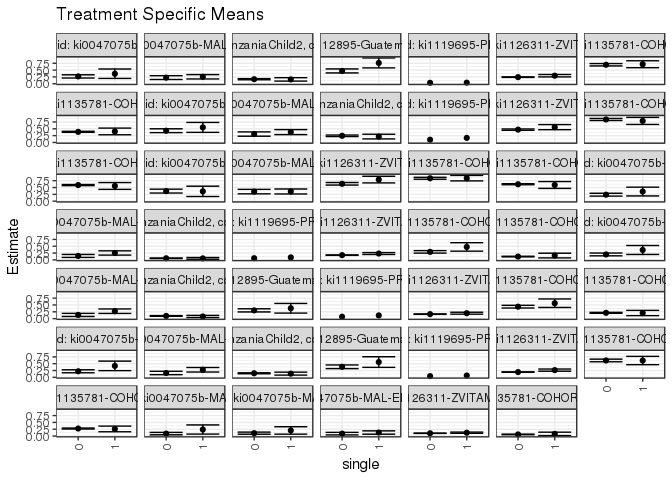

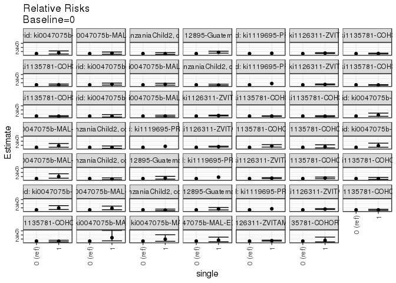

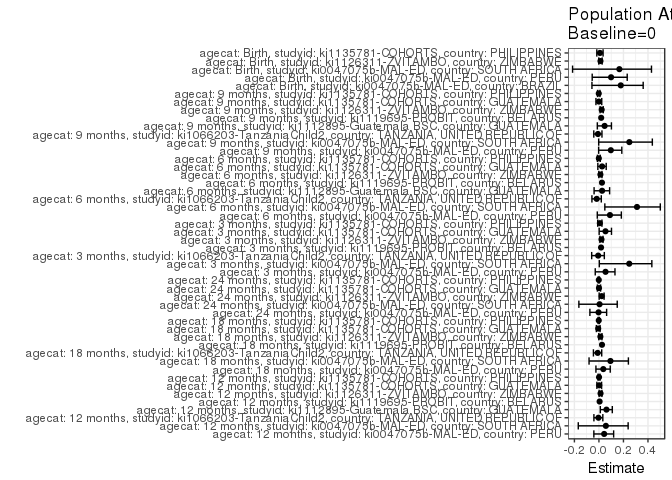

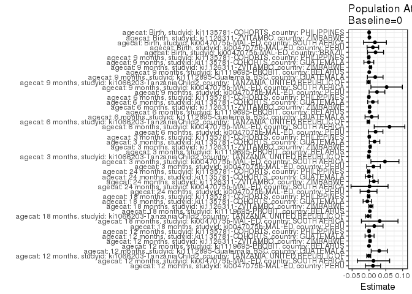

## Results Table

### Parameter: TSM

| agecat | studyid | country | intervention_level | baseline_level | estimate | ci_lower | ci_upper |
| --- | --- | --- | --- | --- | --- | --- | --- |
| Birth | ki0047075b-MAL-ED | BRAZIL | 0 | NA | 0.0903614 | 0.0466334 | 0.1340895 |
| Birth | ki0047075b-MAL-ED | BRAZIL | 1 | NA | 0.2400000 | 0.0721465 | 0.4078535 |
| Birth | ki0047075b-MAL-ED | PERU | 0 | NA | 0.1067194 | 0.0686074 | 0.1448313 |
| Birth | ki0047075b-MAL-ED | PERU | 1 | NA | 0.2058824 | 0.0697321 | 0.3420326 |
| Birth | ki0047075b-MAL-ED | SOUTH AFRICA | 0 | NA | 0.0890411 | 0.0427554 | 0.1353268 |
| Birth | ki0047075b-MAL-ED | SOUTH AFRICA | 1 | NA | 0.1293103 | 0.0681320 | 0.1904887 |
| Birth | ki1126311-ZVITAMBO | ZIMBABWE | 0 | NA | 0.1023097 | 0.0970803 | 0.1075392 |
| Birth | ki1126311-ZVITAMBO | ZIMBABWE | 1 | NA | 0.1229885 | 0.1011643 | 0.1448127 |
| Birth | ki1135781-COHORTS | PHILIPPINES | 0 | NA | 0.0599455 | 0.0513574 | 0.0685336 |
| Birth | ki1135781-COHORTS | PHILIPPINES | 1 | NA | 0.0810811 | 0.0188793 | 0.1432829 |
| 3 months | ki0047075b-MAL-ED | PERU | 0 | NA | 0.2373541 | 0.1852480 | 0.2894602 |
| 3 months | ki0047075b-MAL-ED | PERU | 1 | NA | 0.3529412 | 0.1920326 | 0.5138497 |
| 3 months | ki0047075b-MAL-ED | SOUTH AFRICA | 0 | NA | 0.1446541 | 0.0898819 | 0.1994263 |
| 3 months | ki0047075b-MAL-ED | SOUTH AFRICA | 1 | NA | 0.2540984 | 0.1767085 | 0.3314882 |
| 3 months | ki1066203-TanzaniaChild2 | TANZANIA, UNITED REPUBLIC OF | 0 | NA | 0.0597377 | 0.0494986 | 0.0699769 |
| 3 months | ki1066203-TanzaniaChild2 | TANZANIA, UNITED REPUBLIC OF | 1 | NA | 0.0558140 | 0.0251220 | 0.0865059 |
| 3 months | ki1119695-PROBIT | BELARUS | 0 | NA | 0.0617029 | NA | NA |
| 3 months | ki1119695-PROBIT | BELARUS | 1 | NA | 0.0918367 | NA | NA |
| 3 months | ki1126311-ZVITAMBO | ZIMBABWE | 0 | NA | 0.1742777 | 0.1662524 | 0.1823031 |
| 3 months | ki1126311-ZVITAMBO | ZIMBABWE | 1 | NA | 0.2334495 | 0.1988410 | 0.2680580 |
| 3 months | ki1135781-COHORTS | GUATEMALA | 0 | NA | 0.2944162 | 0.2493599 | 0.3394726 |
| 3 months | ki1135781-COHORTS | GUATEMALA | 1 | NA | 0.4750000 | 0.3200665 | 0.6299335 |
| 3 months | ki1135781-COHORTS | PHILIPPINES | 0 | NA | 0.1220217 | 0.1098305 | 0.1342128 |
| 3 months | ki1135781-COHORTS | PHILIPPINES | 1 | NA | 0.1594203 | 0.0730307 | 0.2458099 |
| 6 months | ki0047075b-MAL-ED | PERU | 0 | NA | 0.2000000 | 0.1493010 | 0.2506990 |
| 6 months | ki0047075b-MAL-ED | PERU | 1 | NA | 0.3636364 | 0.1992089 | 0.5280638 |
| 6 months | ki0047075b-MAL-ED | SOUTH AFRICA | 0 | NA | 0.1357143 | 0.0788706 | 0.1925580 |
| 6 months | ki0047075b-MAL-ED | SOUTH AFRICA | 1 | NA | 0.2719298 | 0.1900895 | 0.3537701 |
| 6 months | ki1066203-TanzaniaChild2 | TANZANIA, UNITED REPUBLIC OF | 0 | NA | 0.0986376 | 0.0849915 | 0.1122837 |
| 6 months | ki1066203-TanzaniaChild2 | TANZANIA, UNITED REPUBLIC OF | 1 | NA | 0.0786517 | 0.0390957 | 0.1182076 |

[output cut: 66 more lines]

### Parameter: E(Y)

| agecat | studyid | country | intervention_level | baseline_level | estimate | ci_lower | ci_upper |
| --- | --- | --- | --- | --- | --- | --- | --- |
| Birth | ki0047075b-MAL-ED | BRAZIL | NA | NA | 0.1099476 | 0.0654669 | 0.1544284 |
| Birth | ki0047075b-MAL-ED | PERU | NA | NA | 0.1184669 | 0.0810142 | 0.1559196 |
| Birth | ki0047075b-MAL-ED | SOUTH AFRICA | NA | NA | 0.1068702 | 0.0693890 | 0.1443514 |
| Birth | ki1126311-ZVITAMBO | ZIMBABWE | NA | NA | 0.1036160 | 0.0985259 | 0.1087061 |
| Birth | ki1135781-COHORTS | PHILIPPINES | NA | NA | 0.0604651 | 0.0519489 | 0.0689813 |
| 3 months | ki0047075b-MAL-ED | PERU | NA | NA | 0.2508591 | 0.2009654 | 0.3007528 |
| 3 months | ki0047075b-MAL-ED | SOUTH AFRICA | NA | NA | 0.1921708 | 0.1460207 | 0.2383209 |
| 3 months | ki1066203-TanzaniaChild2 | TANZANIA, UNITED REPUBLIC OF | NA | NA | 0.0593668 | 0.0496520 | 0.0690815 |
| 3 months | ki1119695-PROBIT | BELARUS | NA | NA | 0.0628025 | NA | NA |
| 3 months | ki1126311-ZVITAMBO | ZIMBABWE | NA | NA | 0.1779865 | 0.1701521 | 0.1858208 |
| 3 months | ki1135781-COHORTS | GUATEMALA | NA | NA | 0.3110599 | 0.2674569 | 0.3546630 |
| 3 months | ki1135781-COHORTS | PHILIPPINES | NA | NA | 0.1229306 | 0.1108500 | 0.1350112 |
| 6 months | ki0047075b-MAL-ED | PERU | NA | NA | 0.2197802 | 0.1705687 | 0.2689917 |
| 6 months | ki0047075b-MAL-ED | SOUTH AFRICA | NA | NA | 0.1968504 | 0.1478551 | 0.2458457 |
| 6 months | ki1066203-TanzaniaChild2 | TANZANIA, UNITED REPUBLIC OF | NA | NA | 0.0968703 | 0.0839461 | 0.1097946 |
| 6 months | ki1112895-Guatemala BSC | GUATEMALA | NA | NA | 0.3104693 | 0.2558835 | 0.3650551 |
| 6 months | ki1119695-PROBIT | BELARUS | NA | NA | 0.0713633 | NA | NA |
| 6 months | ki1126311-ZVITAMBO | ZIMBABWE | NA | NA | 0.1662432 | 0.1582164 | 0.1742700 |
| 6 months | ki1135781-COHORTS | GUATEMALA | NA | NA | 0.4485981 | 0.4014248 | 0.4957715 |
| 6 months | ki1135781-COHORTS | PHILIPPINES | NA | NA | 0.2118834 | 0.1963977 | 0.2273691 |
| 9 months | ki0047075b-MAL-ED | PERU | NA | NA | 0.2460938 | 0.1932265 | 0.2989610 |
| 9 months | ki0047075b-MAL-ED | SOUTH AFRICA | NA | NA | 0.2120000 | 0.1612332 | 0.2627668 |
| 9 months | ki1066203-TanzaniaChild2 | TANZANIA, UNITED REPUBLIC OF | NA | NA | 0.1480023 | 0.1314872 | 0.1645173 |
| 9 months | ki1112895-Guatemala BSC | GUATEMALA | NA | NA | 0.4051724 | 0.3418646 | 0.4684803 |
| 9 months | ki1119695-PROBIT | BELARUS | NA | NA | 0.0449018 | NA | NA |
| 9 months | ki1126311-ZVITAMBO | ZIMBABWE | NA | NA | 0.1975147 | 0.1885898 | 0.2064397 |
| 9 months | ki1135781-COHORTS | GUATEMALA | NA | NA | 0.6182670 | 0.5721340 | 0.6643999 |
| 9 months | ki1135781-COHORTS | PHILIPPINES | NA | NA | 0.2754759 | 0.2585555 | 0.2923963 |
| 12 months | ki0047075b-MAL-ED | PERU | NA | NA | 0.2804878 | 0.2242354 | 0.3367402 |
| 12 months | ki0047075b-MAL-ED | SOUTH AFRICA | NA | NA | 0.2380952 | 0.1854042 | 0.2907863 |
| 12 months | ki1066203-TanzaniaChild2 | TANZANIA, UNITED REPUBLIC OF | NA | NA | 0.1655076 | 0.1462927 | 0.1847226 |
| 12 months | ki1112895-Guatemala BSC | GUATEMALA | NA | NA | 0.5000000 | 0.4305309 | 0.5694691 |
| 12 months | ki1119695-PROBIT | BELARUS | NA | NA | 0.0341262 | NA | NA |
| 12 months | ki1126311-ZVITAMBO | ZIMBABWE | NA | NA | 0.2447948 | 0.2345170 | 0.2550726 |
| 12 months | ki1135781-COHORTS | GUATEMALA | NA | NA | 0.6973415 | 0.6565812 | 0.7381018 |
| 12 months | ki1135781-COHORTS | PHILIPPINES | NA | NA | 0.3886497 | 0.3697454 | 0.4075541 |
| 18 months | ki0047075b-MAL-ED | PERU | NA | NA | 0.4459459 | 0.3804116 | 0.5114803 |
| 18 months | ki0047075b-MAL-ED | SOUTH AFRICA | NA | NA | 0.3402490 | 0.2803070 | 0.4001909 |
| 18 months | ki1066203-TanzaniaChild2 | TANZANIA, UNITED REPUBLIC OF | NA | NA | 0.2415558 | 0.2147027 | 0.2684088 |
| 18 months | ki1119695-PROBIT | BELARUS | NA | NA | 0.1034031 | NA | NA |
| 18 months | ki1126311-ZVITAMBO | ZIMBABWE | NA | NA | 0.4759672 | 0.4522614 | 0.4996729 |
| 18 months | ki1135781-COHORTS | GUATEMALA | NA | NA | 0.8369830 | 0.8012284 | 0.8727375 |
| 18 months | ki1135781-COHORTS | PHILIPPINES | NA | NA | 0.5895977 | 0.5701592 | 0.6090362 |
| 24 months | ki0047075b-MAL-ED | PERU | NA | NA | 0.3681592 | 0.3013164 | 0.4350020 |
| 24 months | ki0047075b-MAL-ED | SOUTH AFRICA | NA | NA | 0.3529412 | 0.2921001 | 0.4137823 |
| 24 months | ki1126311-ZVITAMBO | ZIMBABWE | NA | NA | 0.6513158 | 0.6075279 | 0.6951037 |
| 24 months | ki1135781-COHORTS | GUATEMALA | NA | NA | 0.8395062 | 0.8068385 | 0.8721739 |
| 24 months | ki1135781-COHORTS | PHILIPPINES | NA | NA | 0.6196192 | 0.6002567 | 0.6389817 |

### Parameter: RR

| agecat | studyid | country | intervention_level | baseline_level | estimate | ci_lower | ci_upper |
| --- | --- | --- | --- | --- | --- | --- | --- |
| Birth | ki0047075b-MAL-ED | BRAZIL | 0 | 0 | 1.0000000 | 1.0000000 | 1.000000 |
| Birth | ki0047075b-MAL-ED | BRAZIL | 1 | 0 | 2.6560000 | 1.1346616 | 6.217128 |
| Birth | ki0047075b-MAL-ED | PERU | 0 | 0 | 1.0000000 | 1.0000000 | 1.000000 |
| Birth | ki0047075b-MAL-ED | PERU | 1 | 0 | 1.9291939 | 0.9098576 | 4.090518 |
| Birth | ki0047075b-MAL-ED | SOUTH AFRICA | 0 | 0 | 1.0000000 | 1.0000000 | 1.000000 |
| Birth | ki0047075b-MAL-ED | SOUTH AFRICA | 1 | 0 | 1.4522546 | 0.7190881 | 2.932942 |
| Birth | ki1126311-ZVITAMBO | ZIMBABWE | 0 | 0 | 1.0000000 | 1.0000000 | 1.000000 |
| Birth | ki1126311-ZVITAMBO | ZIMBABWE | 1 | 0 | 1.2021195 | 0.9994220 | 1.445927 |
| Birth | ki1135781-COHORTS | PHILIPPINES | 0 | 0 | 1.0000000 | 1.0000000 | 1.000000 |
| Birth | ki1135781-COHORTS | PHILIPPINES | 1 | 0 | 1.3525799 | 0.6197717 | 2.951849 |
| 3 months | ki0047075b-MAL-ED | PERU | 0 | 0 | 1.0000000 | 1.0000000 | 1.000000 |
| 3 months | ki0047075b-MAL-ED | PERU | 1 | 0 | 1.4869817 | 0.8964970 | 2.466394 |
| 3 months | ki0047075b-MAL-ED | SOUTH AFRICA | 0 | 0 | 1.0000000 | 1.0000000 | 1.000000 |
| 3 months | ki0047075b-MAL-ED | SOUTH AFRICA | 1 | 0 | 1.7565930 | 1.0805209 | 2.855677 |
| 3 months | ki1066203-TanzaniaChild2 | TANZANIA, UNITED REPUBLIC OF | 0 | 0 | 1.0000000 | 1.0000000 | 1.000000 |
| 3 months | ki1066203-TanzaniaChild2 | TANZANIA, UNITED REPUBLIC OF | 1 | 0 | 0.9343165 | 0.5252236 | 1.662049 |
| 3 months | ki1119695-PROBIT | BELARUS | 0 | 0 | 1.0000000 | NA | NA |
| 3 months | ki1119695-PROBIT | BELARUS | 1 | 0 | 1.4883686 | NA | NA |
| 3 months | ki1126311-ZVITAMBO | ZIMBABWE | 0 | 0 | 1.0000000 | 1.0000000 | 1.000000 |
| 3 months | ki1126311-ZVITAMBO | ZIMBABWE | 1 | 0 | 1.3395256 | 1.1469198 | 1.564476 |
| 3 months | ki1135781-COHORTS | GUATEMALA | 0 | 0 | 1.0000000 | 1.0000000 | 1.000000 |
| 3 months | ki1135781-COHORTS | GUATEMALA | 1 | 0 | 1.6133621 | 1.1252751 | 2.313156 |
| 3 months | ki1135781-COHORTS | PHILIPPINES | 0 | 0 | 1.0000000 | 1.0000000 | 1.000000 |
| 3 months | ki1135781-COHORTS | PHILIPPINES | 1 | 0 | 1.3064917 | 0.7530031 | 2.266818 |
| 6 months | ki0047075b-MAL-ED | PERU | 0 | 0 | 1.0000000 | 1.0000000 | 1.000000 |
| 6 months | ki0047075b-MAL-ED | PERU | 1 | 0 | 1.8181818 | 1.0826943 | 3.053295 |
| 6 months | ki0047075b-MAL-ED | SOUTH AFRICA | 0 | 0 | 1.0000000 | 1.0000000 | 1.000000 |
| 6 months | ki0047075b-MAL-ED | SOUTH AFRICA | 1 | 0 | 2.0036934 | 1.1962950 | 3.356018 |
| 6 months | ki1066203-TanzaniaChild2 | TANZANIA, UNITED REPUBLIC OF | 0 | 0 | 1.0000000 | 1.0000000 | 1.000000 |
| 6 months | ki1066203-TanzaniaChild2 | TANZANIA, UNITED REPUBLIC OF | 1 | 0 | 0.7973803 | 0.4732978 | 1.343373 |

[output cut: 66 more lines]

### Parameter: PAR

| agecat | studyid | country | intervention_level | baseline_level | estimate | ci_lower | ci_upper |
| --- | --- | --- | --- | --- | --- | --- | --- |
| Birth | ki0047075b-MAL-ED | BRAZIL | 0 | NA | 0.0195862 | -0.0042246 | 0.0433970 |
| Birth | ki0047075b-MAL-ED | PERU | 0 | NA | 0.0117475 | -0.0054086 | 0.0289037 |
| Birth | ki0047075b-MAL-ED | SOUTH AFRICA | 0 | NA | 0.0178291 | -0.0162228 | 0.0518810 |
| Birth | ki1126311-ZVITAMBO | ZIMBABWE | 0 | NA | 0.0013063 | -0.0001139 | 0.0027265 |
| Birth | ki1135781-COHORTS | PHILIPPINES | 0 | NA | 0.0005196 | -0.0010285 | 0.0020678 |
| 3 months | ki0047075b-MAL-ED | PERU | 0 | NA | 0.0135050 | -0.0067132 | 0.0337233 |
| 3 months | ki0047075b-MAL-ED | SOUTH AFRICA | 0 | NA | 0.0475167 | 0.0058656 | 0.0891678 |
| 3 months | ki1066203-TanzaniaChild2 | TANZANIA, UNITED REPUBLIC OF | 0 | NA | -0.0003710 | -0.0034304 | 0.0026884 |
| 3 months | ki1119695-PROBIT | BELARUS | 0 | NA | 0.0010996 | NA | NA |
| 3 months | ki1126311-ZVITAMBO | ZIMBABWE | 0 | NA | 0.0037087 | 0.0014627 | 0.0059548 |
| 3 months | ki1135781-COHORTS | GUATEMALA | 0 | NA | 0.0166437 | 0.0009797 | 0.0323076 |
| 3 months | ki1135781-COHORTS | PHILIPPINES | 0 | NA | 0.0009089 | -0.0012221 | 0.0030400 |
| 6 months | ki0047075b-MAL-ED | PERU | 0 | NA | 0.0197802 | -0.0019636 | 0.0415241 |
| 6 months | ki0047075b-MAL-ED | SOUTH AFRICA | 0 | NA | 0.0611361 | 0.0156412 | 0.1066310 |
| 6 months | ki1066203-TanzaniaChild2 | TANZANIA, UNITED REPUBLIC OF | 0 | NA | -0.0017673 | -0.0054756 | 0.0019411 |
| 6 months | ki1112895-Guatemala BSC | GUATEMALA | 0 | NA | 0.0080500 | -0.0116153 | 0.0277152 |
| 6 months | ki1119695-PROBIT | BELARUS | 0 | NA | 0.0017628 | NA | NA |
| 6 months | ki1126311-ZVITAMBO | ZIMBABWE | 0 | NA | 0.0019988 | -0.0001560 | 0.0041537 |
| 6 months | ki1135781-COHORTS | GUATEMALA | 0 | NA | 0.0115801 | -0.0037113 | 0.0268715 |
| 6 months | ki1135781-COHORTS | PHILIPPINES | 0 | NA | -0.0001565 | -0.0026317 | 0.0023187 |
| 9 months | ki0047075b-MAL-ED | PERU | 0 | NA | 0.0238715 | 0.0004207 | 0.0473223 |
| 9 months | ki0047075b-MAL-ED | SOUTH AFRICA | 0 | NA | 0.0525797 | 0.0058062 | 0.0993532 |
| 9 months | ki1066203-TanzaniaChild2 | TANZANIA, UNITED REPUBLIC OF | 0 | NA | -0.0011963 | -0.0061379 | 0.0037453 |
| 9 months | ki1112895-Guatemala BSC | GUATEMALA | 0 | NA | 0.0186990 | -0.0045606 | 0.0419586 |
| 9 months | ki1119695-PROBIT | BELARUS | 0 | NA | 0.0008269 | NA | NA |
| 9 months | ki1126311-ZVITAMBO | ZIMBABWE | 0 | NA | 0.0044295 | 0.0018783 | 0.0069808 |
| 9 months | ki1135781-COHORTS | GUATEMALA | 0 | NA | -0.0002897 | -0.0149348 | 0.0143554 |
| 9 months | ki1135781-COHORTS | PHILIPPINES | 0 | NA | -0.0003861 | -0.0030930 | 0.0023207 |
| 12 months | ki0047075b-MAL-ED | PERU | 0 | NA | 0.0119693 | -0.0106664 | 0.0346050 |
| 12 months | ki0047075b-MAL-ED | SOUTH AFRICA | 0 | NA | 0.0134576 | -0.0346335 | 0.0615486 |
| 12 months | ki1066203-TanzaniaChild2 | TANZANIA, UNITED REPUBLIC OF | 0 | NA | -0.0006486 | -0.0066715 | 0.0053744 |
| 12 months | ki1112895-Guatemala BSC | GUATEMALA | 0 | NA | 0.0307263 | 0.0065962 | 0.0548563 |
| 12 months | ki1119695-PROBIT | BELARUS | 0 | NA | 0.0001892 | NA | NA |
| 12 months | ki1126311-ZVITAMBO | ZIMBABWE | 0 | NA | 0.0032297 | 0.0004435 | 0.0060160 |
| 12 months | ki1135781-COHORTS | GUATEMALA | 0 | NA | 0.0018870 | -0.0115233 | 0.0152972 |
| 12 months | ki1135781-COHORTS | PHILIPPINES | 0 | NA | 0.0003625 | -0.0026386 | 0.0033636 |
| 18 months | ki0047075b-MAL-ED | PERU | 0 | NA | 0.0158941 | -0.0100758 | 0.0418641 |
| 18 months | ki0047075b-MAL-ED | SOUTH AFRICA | 0 | NA | 0.0319783 | -0.0223492 | 0.0863057 |
| 18 months | ki1066203-TanzaniaChild2 | TANZANIA, UNITED REPUBLIC OF | 0 | NA | -0.0025387 | -0.0107086 | 0.0056312 |
| 18 months | ki1119695-PROBIT | BELARUS | 0 | NA | 0.0025857 | NA | NA |
| 18 months | ki1126311-ZVITAMBO | ZIMBABWE | 0 | NA | 0.0056732 | -0.0005111 | 0.0118575 |
| 18 months | ki1135781-COHORTS | GUATEMALA | 0 | NA | -0.0048401 | -0.0174053 | 0.0077251 |
| 18 months | ki1135781-COHORTS | PHILIPPINES | 0 | NA | -0.0008189 | -0.0039539 | 0.0023161 |
| 24 months | ki0047075b-MAL-ED | PERU | 0 | NA | -0.0011590 | -0.0262516 | 0.0239336 |
| 24 months | ki0047075b-MAL-ED | SOUTH AFRICA | 0 | NA | 0.0017961 | -0.0532043 | 0.0567966 |
| 24 months | ki1126311-ZVITAMBO | ZIMBABWE | 0 | NA | 0.0145119 | 0.0015502 | 0.0274736 |
| 24 months | ki1135781-COHORTS | GUATEMALA | 0 | NA | 0.0004257 | -0.0106692 | 0.0115206 |
| 24 months | ki1135781-COHORTS | PHILIPPINES | 0 | NA | -0.0006608 | -0.0037641 | 0.0024425 |

### Parameter: PAF

| agecat | studyid | country | intervention_level | baseline_level | estimate | ci_lower | ci_upper |
| --- | --- | --- | --- | --- | --- | --- | --- |
| Birth | ki0047075b-MAL-ED | BRAZIL | 0 | NA | 0.1781411 | -0.0569878 | 0.3609652 |
| Birth | ki0047075b-MAL-ED | PERU | 0 | NA | 0.0991630 | -0.0549019 | 0.2307272 |
| Birth | ki0047075b-MAL-ED | SOUTH AFRICA | 0 | NA | 0.1668297 | -0.2149637 | 0.4286474 |
| Birth | ki1126311-ZVITAMBO | ZIMBABWE | 0 | NA | 0.0126072 | -0.0011836 | 0.0262082 |
| Birth | ki1135781-COHORTS | PHILIPPINES | 0 | NA | 0.0085936 | -0.0173182 | 0.0338454 |
| 3 months | ki0047075b-MAL-ED | PERU | 0 | NA | 0.0538351 | -0.0300090 | 0.1308542 |
| 3 months | ki0047075b-MAL-ED | SOUTH AFRICA | 0 | NA | 0.2472630 | 0.0031204 | 0.4316134 |
| 3 months | ki1066203-TanzaniaChild2 | TANZANIA, UNITED REPUBLIC OF | 0 | NA | -0.0062490 | -0.0591164 | 0.0439794 |
| 3 months | ki1119695-PROBIT | BELARUS | 0 | NA | 0.0175086 | NA | NA |
| 3 months | ki1126311-ZVITAMBO | ZIMBABWE | 0 | NA | 0.0208372 | 0.0081559 | 0.0333563 |
| 3 months | ki1135781-COHORTS | GUATEMALA | 0 | NA | 0.0535063 | 0.0018717 | 0.1024697 |
| 3 months | ki1135781-COHORTS | PHILIPPINES | 0 | NA | 0.0073940 | -0.0100821 | 0.0245677 |
| 6 months | ki0047075b-MAL-ED | PERU | 0 | NA | 0.0900000 | -0.0133927 | 0.1828439 |
| 6 months | ki0047075b-MAL-ED | SOUTH AFRICA | 0 | NA | 0.3105714 | 0.0481228 | 0.5006585 |
| 6 months | ki1066203-TanzaniaChild2 | TANZANIA, UNITED REPUBLIC OF | 0 | NA | -0.0182436 | -0.0571908 | 0.0192689 |
| 6 months | ki1112895-Guatemala BSC | GUATEMALA | 0 | NA | 0.0259284 | -0.0394954 | 0.0872345 |
| 6 months | ki1119695-PROBIT | BELARUS | 0 | NA | 0.0247017 | NA | NA |
| 6 months | ki1126311-ZVITAMBO | ZIMBABWE | 0 | NA | 0.0120235 | -0.0010160 | 0.0248931 |
| 6 months | ki1135781-COHORTS | GUATEMALA | 0 | NA | 0.0258141 | -0.0089418 | 0.0593727 |
| 6 months | ki1135781-COHORTS | PHILIPPINES | 0 | NA | -0.0007385 | -0.0124887 | 0.0108754 |
| 9 months | ki0047075b-MAL-ED | PERU | 0 | NA | 0.0970018 | -0.0024560 | 0.1865919 |
| 9 months | ki0047075b-MAL-ED | SOUTH AFRICA | 0 | NA | 0.2480175 | -0.0019581 | 0.4356274 |
| 9 months | ki1066203-TanzaniaChild2 | TANZANIA, UNITED REPUBLIC OF | 0 | NA | -0.0080828 | -0.0420223 | 0.0247513 |
| 9 months | ki1112895-Guatemala BSC | GUATEMALA | 0 | NA | 0.0461507 | -0.0131625 | 0.1019915 |
| 9 months | ki1119695-PROBIT | BELARUS | 0 | NA | 0.0184165 | NA | NA |
| 9 months | ki1126311-ZVITAMBO | ZIMBABWE | 0 | NA | 0.0224264 | 0.0094449 | 0.0352377 |
| 9 months | ki1135781-COHORTS | GUATEMALA | 0 | NA | -0.0004686 | -0.0244386 | 0.0229406 |
| 9 months | ki1135781-COHORTS | PHILIPPINES | 0 | NA | -0.0014017 | -0.0112760 | 0.0083761 |
| 12 months | ki0047075b-MAL-ED | PERU | 0 | NA | 0.0426731 | -0.0414018 | 0.1199605 |
| 12 months | ki0047075b-MAL-ED | SOUTH AFRICA | 0 | NA | 0.0565217 | -0.1685133 | 0.2382190 |
| 12 months | ki1066203-TanzaniaChild2 | TANZANIA, UNITED REPUBLIC OF | 0 | NA | -0.0039186 | -0.0409751 | 0.0318188 |
| 12 months | ki1112895-Guatemala BSC | GUATEMALA | 0 | NA | 0.0614525 | 0.0112372 | 0.1091176 |
| 12 months | ki1119695-PROBIT | BELARUS | 0 | NA | 0.0055444 | NA | NA |
| 12 months | ki1126311-ZVITAMBO | ZIMBABWE | 0 | NA | 0.0131937 | 0.0017506 | 0.0245055 |
| 12 months | ki1135781-COHORTS | GUATEMALA | 0 | NA | 0.0027059 | -0.0167136 | 0.0217546 |
| 12 months | ki1135781-COHORTS | PHILIPPINES | 0 | NA | 0.0009327 | -0.0068190 | 0.0086248 |
| 18 months | ki0047075b-MAL-ED | PERU | 0 | NA | 0.0356414 | -0.0245265 | 0.0922758 |
| 18 months | ki0047075b-MAL-ED | SOUTH AFRICA | 0 | NA | 0.0939850 | -0.0805514 | 0.2403293 |
| 18 months | ki1066203-TanzaniaChild2 | TANZANIA, UNITED REPUBLIC OF | 0 | NA | -0.0105098 | -0.0448969 | 0.0227457 |
| 18 months | ki1119695-PROBIT | BELARUS | 0 | NA | 0.0250060 | NA | NA |
| 18 months | ki1126311-ZVITAMBO | ZIMBABWE | 0 | NA | 0.0119194 | -0.0011705 | 0.0248381 |
| 18 months | ki1135781-COHORTS | GUATEMALA | 0 | NA | -0.0057828 | -0.0209271 | 0.0091369 |
| 18 months | ki1135781-COHORTS | PHILIPPINES | 0 | NA | -0.0013890 | -0.0067207 | 0.0039145 |
| 24 months | ki0047075b-MAL-ED | PERU | 0 | NA | -0.0031480 | -0.0736742 | 0.0627455 |
| 24 months | ki0047075b-MAL-ED | SOUTH AFRICA | 0 | NA | 0.0050891 | -0.1636132 | 0.1493326 |
| 24 months | ki1126311-ZVITAMBO | ZIMBABWE | 0 | NA | 0.0222809 | 0.0020242 | 0.0421265 |
| 24 months | ki1135781-COHORTS | GUATEMALA | 0 | NA | 0.0005071 | -0.0127968 | 0.0136363 |
| 24 months | ki1135781-COHORTS | PHILIPPINES | 0 | NA | -0.0010665 | -0.0060877 | 0.0039297 |